# Final project

Adriana Gutierrez Yllu

2025-11-06

# Introduction

This dataset captures participants’ initial visit to a pilot program designed to enhance awareness and facilitate early detection of hypertension through free blood pressure screenings and a brief educational session on lifestyle modification. Despite these efforts the program has not achieved the intended level of reach.

The first objective of this process evaluation report is to identify key barriers and facilitators influencing participation in the pilot hypertension screening program.

The second objective is to assess participants’ preferences from the pilot program to inform the implementation of the full- scale program.

### Table 1. Baseline characteristics of participants

Table 1 summarizes the baseline characteristics of participants in the pilot hypertension screening program, stratified by age group (≤50 years and >50 years). All the participants were Hispanic.

Most participants reported having health insurance, though coverage was more consistent among those over 50 years (100% (4/4)) compared to younger participants (60% (3/5)). A greater proportion of younger participants were actively working (80% (4/5)) vs. older participants (50% (2/4)). Nutrition talks were reported more often by older participants (75% (3/4)) compared with younger participants (40% (2/5)).

Regarding health history, a personal history of hypertension was reported by both age groups (67% (6/9)), and family history of hypertension was more common among younger participants (60% (3/5)) than older participants (25% (1/4)).

| **Characteristic** | **Overall** N = 9<sup>1</sup> | **Participants stratified by age** **50 years or younger** N = 5<sup>1</sup> | **Participants stratified by age** **Over 50 years** N = 4<sup>1</sup> | **p-value**<sup>2</sup> |  |
| --- | --- | --- | --- | --- | --- |
| Gender |  |  |  |  | >0.9 |
| female | 5 (56%) | 3 (60%) | 2 (50%) |  |  |
| male | 4 (44%) | 2 (40%) | 2 (50%) |  |  |
| Race |  |  |  | >0.9 |  |
| Prefer not to answer | 4 (44%) | 2 (40%) | 2 (50%) |  |  |
| unsure | 2 (22%) | 1 (20%) | 1 (25%) |  |  |
| white | 3 (33%) | 2 (40%) | 1 (25%) |  |  |
| Ethnicity |  |  |  |  |  |
| Hispanic | 9 (100%) | 5 (100%) | 4 (100%) |  |  |
| Insurance | 7 (78%) | 3 (60%) | 4 (100%) | 0.4 |  |
| Actively working | 6 (67%) | 4 (80%) | 2 (50%) | 0.5 |  |
| Nutrition talk ever | 5 (56%) | 2 (40%) | 3 (75%) | 0.5 |  |
| Daily consumption of fast food |  |  |  | 0.3 |  |
| 1 - 2 times/day | 2 (22%) | 2 (40%) | 0 (0%) |  |  |
| everyday | 1 (11%) | 1 (20%) | 0 (0%) |  |  |
| rare | 6 (67%) | 2 (40%) | 4 (100%) |  |  |
| Sweetened beverages |  |  |  | >0.9 |  |
| 1-3 times/week | 5 (56%) | 2 (40%) | 3 (75%) |  |  |
| 1/d | 2 (22%) | 1 (20%) | 1 (25%) |  |  |
| 2/d | 1 (11%) | 1 (20%) | 0 (0%) |  |  |
| never | 1 (11%) | 1 (20%) | 0 (0%) |  |  |
| Daily consusmtion of vaggies |  |  |  | >0.9 |  |
| 1 - 2 times/day | 2 (22%) | 1 (20%) | 1 (25%) |  |  |
| 3-4 times/day | 1 (11%) | 1 (20%) | 0 (0%) |  |  |
| less than 1/day | 4 (44%) | 2 (40%) | 2 (50%) |  |  |
| Prefer not to answer | 1 (11%) | 0 (0%) | 1 (25%) |  |  |
| rare | 1 (11%) | 1 (20%) | 0 (0%) |  |  |
| Challenges to consume healthy food |  |  |  | >0.9 |  |
| Don’t know how to prepare | 2 (29%) | 1 (25%) | 1 (33%) |  |  |
| No talks about it | 1 (14%) | 1 (25%) | 0 (0%) |  |  |
| No time | 4 (57%) | 2 (50%) | 2 (67%) |  |  |
| Unknown | 2 | 1 | 1 |  |  |
| Previous diagnosis of Hypertension | 6 (67%) | 3 (60%) | 3 (75%) | >0.9 |  |
| Family member with hypertension |  |  |  | 0.4 |  |
| Don’t know | 3 (33%) | 2 (40%) | 1 (25%) |  |  |
| No | 2 (22%) | 0 (0%) | 2 (50%) |  |  |
| Yes | 4 (44%) | 3 (60%) | 1 (25%) |  |  |

<sup>1</sup> n (%)  
<sup>2</sup> Fisher’s exact test; NA

### Figure 1. Suggestions to Reach More People by Age Group

This figure presents participants’ suggestions on how to reach more people with the hypertension screening program, stratified by age group.

Among younger participants, the most common suggestions were increasing advertising (40%) and “don’t know” (40%). In contrast, older participants most frequently recommended visiting churches (50%).

These findings suggest that oureach preferences differ by age group. Younger participants favored broad adverising and school-based approches, reflecting their likely engagement with medica and edicational settings. Older participants emphasized churches as trusted community spaces, highlighting the role of faith-based organizations in program dissemination.

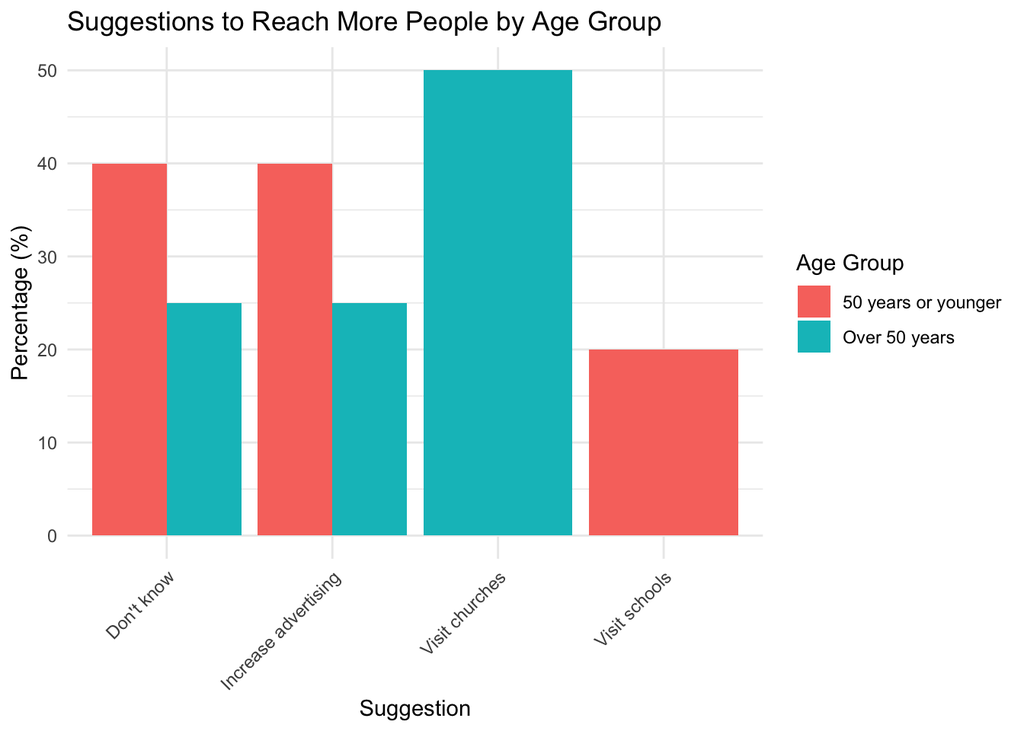

.